# Visualisasi Data Menggunakan ggplot2

Ameliatus Sholichah-Institut Teknologi Statistika dan Bisnis Muhammadiyah

2025-01-09

# Pengantar ggplot2

ggplot2 adalah paket R untuk menghasilkan visualisasi data. Tidak seperti banyak paket grafik, ggplot2 menggunakan kerangka konseptual berdasarkan tata bahasa grafik. Hal ini memungkinkan Anda untuk ‘mengucapkan’ grafik dari elemen yang dapat disusun, alih-alih dibatasi pada serangkaian diagram yang telah ditentukan sebelumnya.

ggplot2 adalah paket R yang digunakan untuk membuat visualisasi data yang elegan dan informatif. Paket ini dikembangkan oleh Hadley Wickham dan didasarkan pada prinsip Grammar of Graphics, yang memungkinkan pengguna untuk membangun grafik dengan cara yang terstruktur dan intuitif.

ggplot2 adalah alat yang sangat kuat untuk visualisasi data di R. Dengan pemahaman dasar tentang cara kerjanya, Anda dapat mulai membuat grafik yang menarik dan informatif untuk analisis data Anda.

# Dasar-Dasar ggplot2

## Introduction

Analisis data sering kali melibatkan visualisasi. Beberapa wawasan yang mungkin tidak tampak dalam angka-angka dapat muncul dengan lebih mudah jika divisualisasikan. Visualisasi semacam itu dapat membantu menghasilkan model statistik yang sesuai untuk mengotomatiskan tugas menggambar kesimpulan dari data.

**Berikut adalah beberapa konsep dasar ggplot2 yang perlu Anda pahami:**

**1. Data Frame** ggplot2 bekerja dengan data yang disimpan dalam bentuk data frame. Data frame adalah struktur data yang mirip dengan tabel, di mana setiap kolom dapat berisi tipe data yang berbeda (numerik, faktor, karakter, dll.).

**2. Estetika (Aesthetics)** Estetika adalah cara untuk menghubungkan variabel dalam data Anda dengan elemen visual dalam grafik. Dalam ggplot2, estetika didefinisikan menggunakan fungsi aes(). Contoh estetika yang umum digunakan adalah:

**x**: Variabel untuk sumbu x. **y**: Variabel untuk sumbu y. **color**: Warna titik atau garis berdasarkan variabel. **size**: Ukuran titik berdasarkan variabel. **shape**: Bentuk titik berdasarkan variabel.

**Contoh Penggunaan Estetika dalam merubah warna pada setiap grup:**

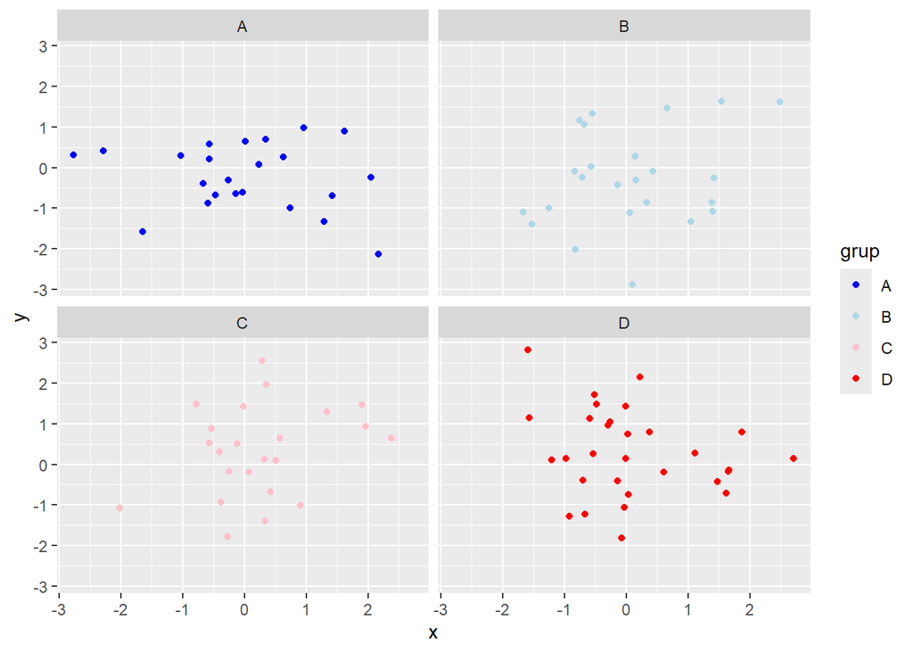

```r
library(ggplot2)
data <- data.frame(x=rnorm(100),y= rnorm(100), grup = sample(c("A","B","C","D"), 100, replace = TRUE))
ggplot(data, aes(x=x,y=y,color=grup))+
      geom_point()+
      facet_wrap(~grup)+
      scale_color_manual(values = c("A"="blue", "B"="lightblue","C"="pink","D"="red"))
```

**3. Geometri (Geometries)** Geometri adalah elemen visual yang Anda tambahkan ke grafik. Setiap jenis grafik memiliki geometri yang berbeda. Beberapa geometri yang umum digunakan adalah:

**geom_point():** Untuk membuat scatter plot. **geom_line():** Untuk membuat grafik garis. **geom_bar():** Untuk membuat grafik batang. **geom_histogram():** Untuk membuat histogram. **geom_boxplot():** Untuk membuat boxplot.

## Contoh Implementasi ggplot2

1. Implementasi ggplot2 dari data random

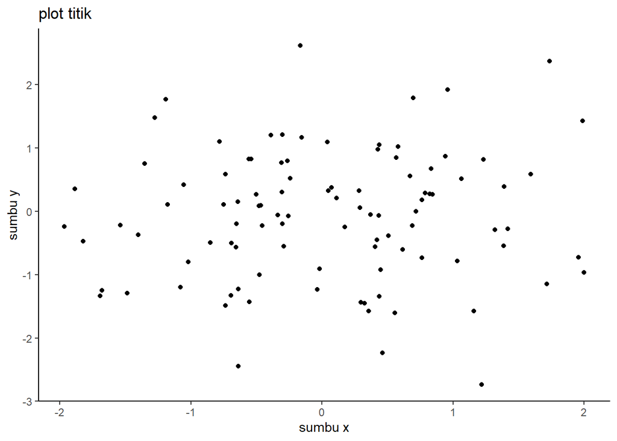

```r
library(ggplot2)
data <- data.frame(x=rnorm(100),y= rnorm(100))
ggplot(data, aes(x=y,y=x))+
      geom_point()+
      labs(title = "plot titik", x="sumbu x", y="sumbu y")+
        theme_classic()
```

2. Implementasi ggplot2 dari file csv

```r
library(readr)
lizard <- read.csv("lizards.csv")
View(lizard)
```

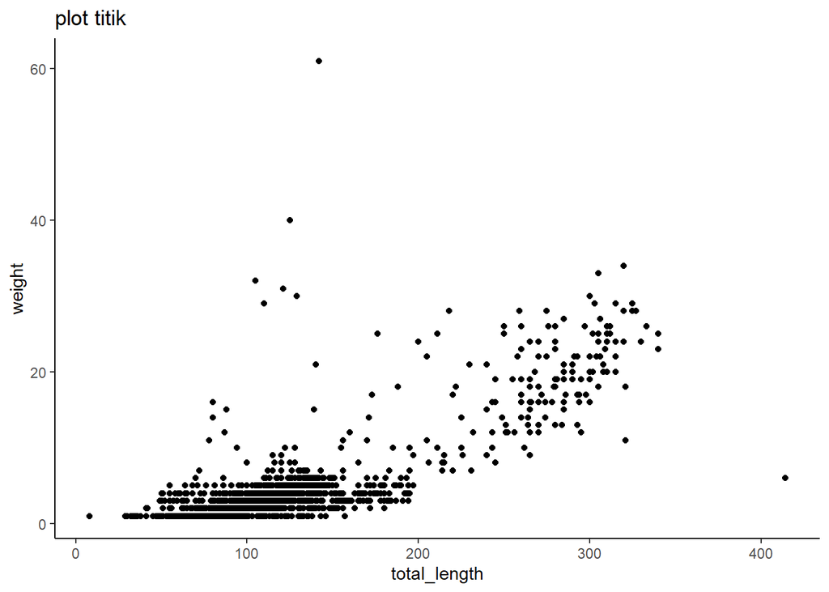

```r
library(ggplot2)
ggplot(lizard, aes(x=total_length,y=weight))+
      geom_point()+
      labs(title = "plot titik", x="total_length", y="weight")+
        theme_classic()
```

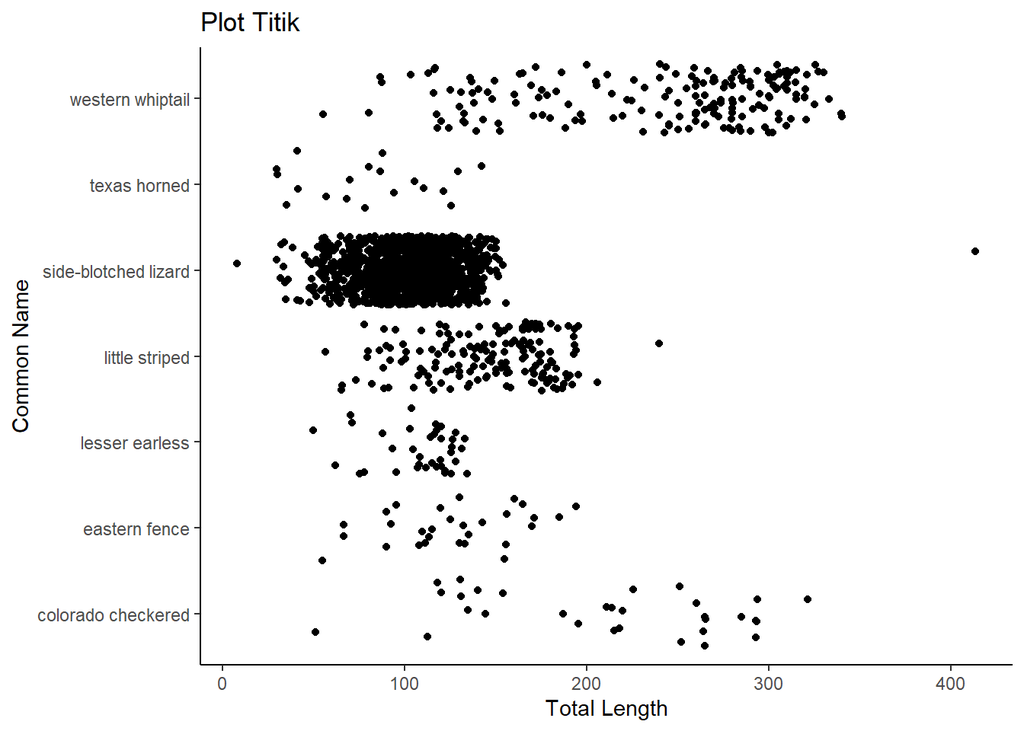

```r
library(ggplot2)
ggplot(lizard, aes(x=total_length,y=common_name))+
      geom_jitter()+
      labs(title = "Plot Titik", x="Total Length", y="Common Name")+
        theme_classic()
```

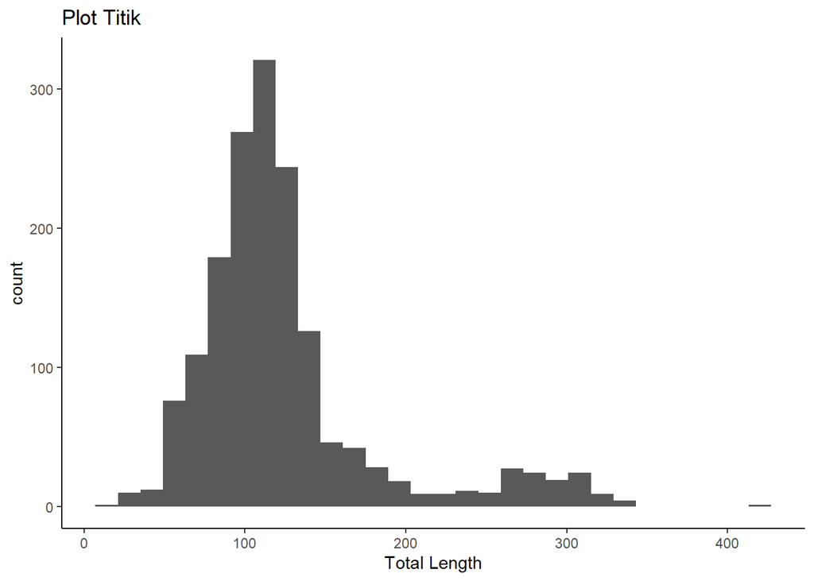

```r
library(ggplot2)
ggplot(lizard, aes(x=total_length))+
      geom_histogram()+
      labs(title = "Plot Titik", x="Total Length")+
        theme_classic()
```

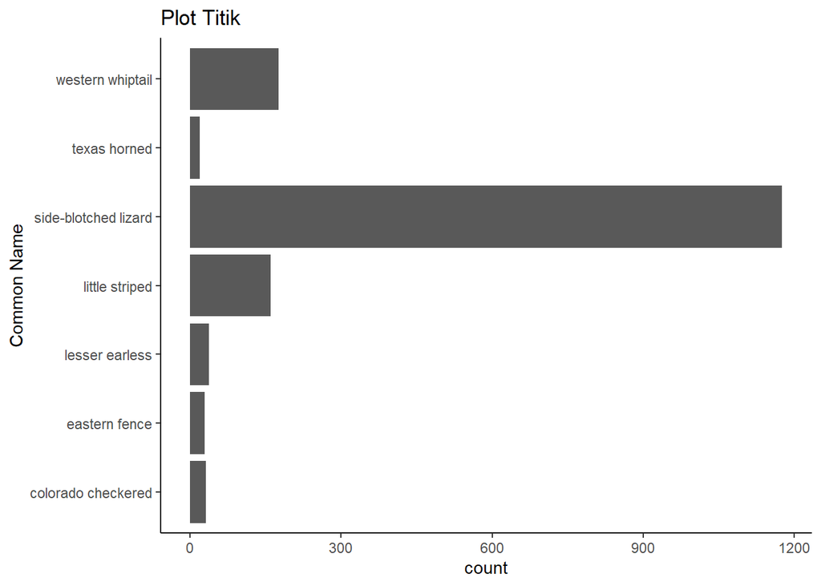

```r
library(ggplot2)
ggplot(lizard, aes(y=common_name))+
      geom_bar()+
      labs(title = "Plot Titik", y="Common Name")+
        theme_classic()
```

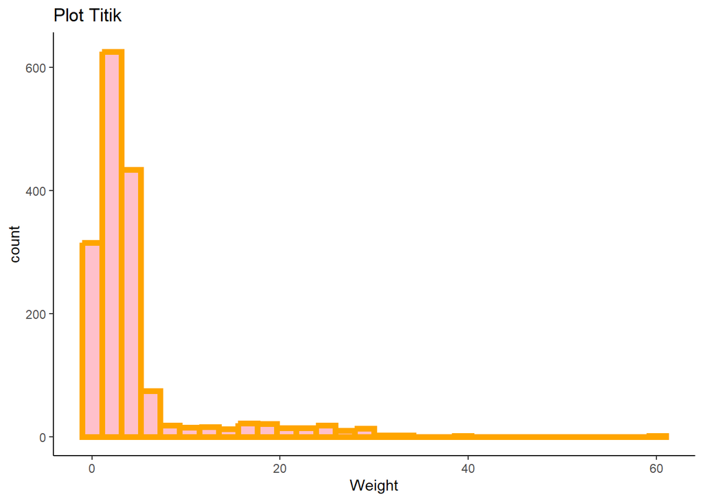

```r
library(ggplot2)
ggplot(lizard, aes(x=weight))+
      geom_histogram(colour="orange",fill="pink",size=2,line=".")+
      labs(title = "Plot Titik", x="Weight")+
        theme_classic()
```